# DS220 Project 2: Analyzing Data From the FIA Formula 1 World Championship

**Jacob Lukasik & Reyhaan Sethi**

For this project, we have found a very vast dataset regarding the FIA Formula 1 World Championship which contains Driver and Constructor information as well as, lap times, race results, and pit stop data from the inaugural season of the FIA Formula 1 World Championship, 1950, all the way up to the end of the 2023 season. With this dataset, we are striving to find and assess any connections that may be found that can show the relationships between pit stop times and race success, lap time falloff and race success, etc.

# Step 1: Importing Neccessary Packages

```python
import numpy as np
import matplotlib.pyplot as plt
import pandas as pd
```

# Step 2: Importing CSV Files

```python
circuits = pd.read_csv('circuits.csv')
con_results = pd.read_csv('constructor_results.csv')
con_standings = pd.read_csv('constructor_standings.csv')
constructors = pd.read_csv('constructors.csv')
driver_standings = pd.read_csv('driver_standings.csv')
drivers = pd.read_csv('drivers.csv')
lap_times = pd.read_csv('lap_times.csv')
pit_stops = pd.read_csv('pit_stops.csv')
quali = pd.read_csv('qualifying.csv')
races = pd.read_csv('races.csv')
results = pd.read_csv('results.csv')
seasons = pd.read_csv('seasons.csv')
sprint_result = pd.read_csv('sprint_results.csv')
status = pd.read_csv('status.csv')

# The below lines merges the results, races, and drivers csvs into one data
# frame which contains all information relating to the driver and how they did at any given race
races_results = pd.merge(races, results, on='raceId')
races_results_drivers = pd.merge(races_results, drivers, on = 'driverId')
results_all = pd.merge(races_results_drivers, constructors, on = 'constructorId')
results_all.head(5)
```

|  | raceId | year | round | circuitId | name_x | date | time_x | url_x | fp1_date | fp1_time | ... | code | forename | surname | dob | nationality_x | url_y | constructorRef | name_y | nationality_y | url |
| --- | --- | --- | --- | --- | --- | --- | --- | --- | --- | --- | --- | --- | --- | --- | --- | --- | --- | --- | --- | --- | --- |
| 0 | 1 | 2009 | 1 | 1 | Australian Grand Prix | 2009-03-29 | 06:00:00 | http://en.wikipedia.org/wiki/2009_Australian_G... | \N | \N | ... | BUT | Jenson | Button | 1980-01-19 | British | http://en.wikipedia.org/wiki/Jenson_Button | brawn | Brawn | British | http://en.wikipedia.org/wiki/Brawn_GP |
| 1 | 2 | 2009 | 2 | 2 | Malaysian Grand Prix | 2009-04-05 | 09:00:00 | http://en.wikipedia.org/wiki/2009_Malaysian_Gr... | \N | \N | ... | BUT | Jenson | Button | 1980-01-19 | British | http://en.wikipedia.org/wiki/Jenson_Button | brawn | Brawn | British | http://en.wikipedia.org/wiki/Brawn_GP |
| 2 | 3 | 2009 | 3 | 17 | Chinese Grand Prix | 2009-04-19 | 07:00:00 | http://en.wikipedia.org/wiki/2009_Chinese_Gran... | \N | \N | ... | BUT | Jenson | Button | 1980-01-19 | British | http://en.wikipedia.org/wiki/Jenson_Button | brawn | Brawn | British | http://en.wikipedia.org/wiki/Brawn_GP |
| 3 | 4 | 2009 | 4 | 3 | Bahrain Grand Prix | 2009-04-26 | 12:00:00 | http://en.wikipedia.org/wiki/2009_Bahrain_Gran... | \N | \N | ... | BUT | Jenson | Button | 1980-01-19 | British | http://en.wikipedia.org/wiki/Jenson_Button | brawn | Brawn | British | http://en.wikipedia.org/wiki/Brawn_GP |
| 4 | 5 | 2009 | 5 | 4 | Spanish Grand Prix | 2009-05-10 | 12:00:00 | http://en.wikipedia.org/wiki/2009_Spanish_Gran... | \N | \N | ... | BUT | Jenson | Button | 1980-01-19 | British | http://en.wikipedia.org/wiki/Jenson_Button | brawn | Brawn | British | http://en.wikipedia.org/wiki/Brawn_GP |

5 rows × 47 columns

**Worth noting:** Since we have such a large amount of data as well as specific queries that we know what type of data we will need, any sort of cleaning/processing of data will be done with that specific query and will be documented there.

# Step 3: Developing Questions

# Understanding the Data

## Query 1

For this query, we want to look at all pole positions (first place in qualifying), and see how many times that translated into a grand prix win, as well as how many times that translated into a podium (top three in the grand prix).

**Possible Errors**: Since qualifying was not greatly recorded in Formula 1 until the late 1990s, this data will reflect that as reliable data for qualifying runs earlier than that is inaccesible.

```python
first_place_quali = quali[quali['position'] == 1]
first_place_quali.head(5)
```

|  | qualifyId | raceId | driverId | constructorId | number | position | q1 | q2 | q3 |
| --- | --- | --- | --- | --- | --- | --- | --- | --- | --- |
| 0 | 1 | 18 | 1 | 1 | 22 | 1 | 1:26.572 | 1:25.187 | 1:26.714 |
| 22 | 23 | 19 | 13 | 6 | 2 | 1 | 1:35.347 | 1:34.412 | 1:35.748 |
| 44 | 45 | 20 | 9 | 2 | 4 | 1 | 1:32.893 | 1:31.745 | 1:33.096 |
| 66 | 67 | 21 | 8 | 6 | 1 | 1 | 1:20.701 | 1:20.784 | 1:21.813 |
| 88 | 89 | 22 | 13 | 6 | 2 | 1 | 1:25.994 | 1:26.192 | 1:27.617 |

Now we have all first place qualifying runs saved to our data frame named 'first_place_quali'. From here, lets compare the driverIds for each respective race and see what positon they came in in those respective races and we can get a count of how many of those were P1 as well as P1, P2, or P3.

```python
first_place_quali
```

|  | qualifyId | raceId | driverId | constructorId | number | position | q1 | q2 | q3 |
| --- | --- | --- | --- | --- | --- | --- | --- | --- | --- |
| 0 | 1 | 18 | 1 | 1 | 22 | 1 | 1:26.572 | 1:25.187 | 1:26.714 |
| 22 | 23 | 19 | 13 | 6 | 2 | 1 | 1:35.347 | 1:34.412 | 1:35.748 |
| 44 | 45 | 20 | 9 | 2 | 4 | 1 | 1:32.893 | 1:31.745 | 1:33.096 |
| 66 | 67 | 21 | 8 | 6 | 1 | 1 | 1:20.701 | 1:20.784 | 1:21.813 |
| 88 | 89 | 22 | 13 | 6 | 2 | 1 | 1:25.994 | 1:26.192 | 1:27.617 |
| ... | ... | ... | ... | ... | ... | ... | ... | ... | ... |
| 9715 | 9773 | 1106 | 830 | 9 | 1 | 1 | 1:20.851 | 1:19.092 | 1:25.858 |
| 9735 | 9793 | 1107 | 830 | 9 | 1 | 1 | 1:05.116 | 1:04.951 | 1:04.391 |
| 9755 | 9813 | 1108 | 830 | 9 | 1 | 1 | 1:29.428 | 1:27.702 | 1:26.720 |
| 9775 | 9833 | 1109 | 1 | 131 | 44 | 1 | 1:18.577 | 1:17.427 | 1:16.609 |
| 9795 | 9853 | 1110 | 830 | 9 | 1 | 1 | 1:58.515 | 1:52.784 | 1:46.168 |

460 rows × 9 columns

The above output shows us how many instances of a first place qualifying we have seen in the history of Formula 1. This is the number we can compare when we find the desired results stated in the previous text block.

```python
quali_and_results = pd.merge(first_place_quali, results, on=['raceId', 'driverId'])
winning_drivers_pole = quali_and_results[(quali_and_results['position_x'] == 1) & (quali_and_results['positionOrder'] == 1)]
winning_drivers_pole
```

|  | qualifyId | raceId | driverId | constructorId_x | number_x | position_x | q1 | q2 | q3 | resultId | ... | positionOrder | points | laps | time | milliseconds | fastestLap | rank | fastestLapTime | fastestLapSpeed | statusId |
| --- | --- | --- | --- | --- | --- | --- | --- | --- | --- | --- | --- | --- | --- | --- | --- | --- | --- | --- | --- | --- | --- |
| 0 | 1 | 18 | 1 | 1 | 22 | 1 | 1:26.572 | 1:25.187 | 1:26.714 | 1 | ... | 1 | 10.0 | 58 | 1:34:50.616 | 5690616 | 39 | 2 | 1:27.452 | 218.300 | 1 |
| 3 | 67 | 21 | 8 | 6 | 1 | 1 | 1:20.701 | 1:20.784 | 1:21.813 | 67 | ... | 1 | 10.0 | 66 | 1:38:19.051 | 5899051 | 46 | 1 | 1:21.670 | 205.191 | 1 |
| 4 | 89 | 22 | 13 | 6 | 2 | 1 | 1:25.994 | 1:26.192 | 1:27.617 | 89 | ... | 1 | 10.0 | 58 | 1:26:49.451 | 5209451 | 16 | 3 | 1:26.666 | 221.734 | 1 |
| 9 | 189 | 27 | 1 | 1 | 22 | 1 | 1:15.218 | 1:14.603 | 1:15.666 | 189 | ... | 1 | 10.0 | 67 | 1:31:20.874 | 5480874 | 17 | 2 | 1:16.039 | 216.552 | 1 |
| 11 | 229 | 29 | 13 | 6 | 2 | 1 | 1:38.176 | 1:37.859 | 1:38.989 | 229 | ... | 1 | 10.0 | 57 | 1:35:32.339 | 5732339 | 36 | 1 | 1:38.708 | 197.637 | 1 |
| ... | ... | ... | ... | ... | ... | ... | ... | ... | ... | ... | ... | ... | ... | ... | ... | ... | ... | ... | ... | ... | ... |
| 454 | 9753 | 1105 | 830 | 9 | 1 | 1 | 1:13.615 | 1:12.760 | 1:12.272 | 25966 | ... | 1 | 26.0 | 66 | 1:27:57.940 | 5277940 | 61 | 1 | 1:16.330 | 219.641 | 1 |
| 455 | 9773 | 1106 | 830 | 9 | 1 | 1 | 1:20.851 | 1:19.092 | 1:25.858 | 25986 | ... | 1 | 25.0 | 70 | 1:33:58.348 | 5638348 | 68 | 3 | 1:15.594 | 207.683 | 1 |
| 456 | 9793 | 1107 | 830 | 9 | 1 | 1 | 1:05.116 | 1:04.951 | 1:04.391 | 26006 | ... | 1 | 26.0 | 71 | 1:25:33.607 | 5133607 | 71 | 1 | 1:07.012 | 231.970 | 1 |
| 457 | 9813 | 1108 | 830 | 9 | 1 | 1 | 1:29.428 | 1:27.702 | 1:26.720 | 26026 | ... | 1 | 26.0 | 52 | 1:25:16.938 | 5116938 | 42 | 1 | 1:30.275 | 234.922 | 1 |
| 459 | 9853 | 1110 | 830 | 9 | 1 | 1 | 1:58.515 | 1:52.784 | 1:46.168 | 26066 | ... | 1 | 25.0 | 44 | 1:22:30.450 | 4950450 | 32 | 2 | 1:48.922 | 231.490 | 1 |

230 rows × 25 columns

From the above code, we can see that out of all drivers to qualify in first place for a grand prix, 230 of them went on to win the race. Using the number above for the total amount to qualify in first place we can find the overall win rate:

230 / 460 = 0.5

This means that exactly half of all drivers, 50%, to qualify in first place have went on to win the respective grand prix.

Lets now reuse our code from the last chunk to check for how many drivers finished the race on the podium.

```python
podium_drivers = quali_and_results[(quali_and_results['position_x'] == 1) & (quali_and_results['positionOrder'].isin([1, 2, 3]))]
podium_drivers
```

|  | qualifyId | raceId | driverId | constructorId_x | number_x | position_x | q1 | q2 | q3 | resultId | ... | positionOrder | points | laps | time | milliseconds | fastestLap | rank | fastestLapTime | fastestLapSpeed | statusId |
| --- | --- | --- | --- | --- | --- | --- | --- | --- | --- | --- | --- | --- | --- | --- | --- | --- | --- | --- | --- | --- | --- |
| 0 | 1 | 18 | 1 | 1 | 22 | 1 | 1:26.572 | 1:25.187 | 1:26.714 | 1 | ... | 1 | 10.0 | 58 | 1:34:50.616 | 5690616 | 39 | 2 | 1:27.452 | 218.300 | 1 |
| 2 | 45 | 20 | 9 | 2 | 4 | 1 | 1:32.893 | 1:31.745 | 1:33.096 | 47 | ... | 3 | 6.0 | 57 | +4.998 | 5471968 | 55 | 5 | 1:33.775 | 207.765 | 1 |
| 3 | 67 | 21 | 8 | 6 | 1 | 1 | 1:20.701 | 1:20.784 | 1:21.813 | 67 | ... | 1 | 10.0 | 66 | 1:38:19.051 | 5899051 | 46 | 1 | 1:21.670 | 205.191 | 1 |
| 4 | 89 | 22 | 13 | 6 | 2 | 1 | 1:25.994 | 1:26.192 | 1:27.617 | 89 | ... | 1 | 10.0 | 58 | 1:26:49.451 | 5209451 | 16 | 3 | 1:26.666 | 221.734 | 1 |
| 5 | 109 | 23 | 13 | 6 | 2 | 1 | 1:15.190 | 1:15.110 | 1:15.787 | 111 | ... | 3 | 6.0 | 76 | +4.811 | 7247553 | 76 | 4 | 1:17.886 | 154.379 | 1 |
| ... | ... | ... | ... | ... | ... | ... | ... | ... | ... | ... | ... | ... | ... | ... | ... | ... | ... | ... | ... | ... | ... |
| 454 | 9753 | 1105 | 830 | 9 | 1 | 1 | 1:13.615 | 1:12.760 | 1:12.272 | 25966 | ... | 1 | 26.0 | 66 | 1:27:57.940 | 5277940 | 61 | 1 | 1:16.330 | 219.641 | 1 |
| 455 | 9773 | 1106 | 830 | 9 | 1 | 1 | 1:20.851 | 1:19.092 | 1:25.858 | 25986 | ... | 1 | 25.0 | 70 | 1:33:58.348 | 5638348 | 68 | 3 | 1:15.594 | 207.683 | 1 |
| 456 | 9793 | 1107 | 830 | 9 | 1 | 1 | 1:05.116 | 1:04.951 | 1:04.391 | 26006 | ... | 1 | 26.0 | 71 | 1:25:33.607 | 5133607 | 71 | 1 | 1:07.012 | 231.970 | 1 |
| 457 | 9813 | 1108 | 830 | 9 | 1 | 1 | 1:29.428 | 1:27.702 | 1:26.720 | 26026 | ... | 1 | 26.0 | 52 | 1:25:16.938 | 5116938 | 42 | 1 | 1:30.275 | 234.922 | 1 |
| 459 | 9853 | 1110 | 830 | 9 | 1 | 1 | 1:58.515 | 1:52.784 | 1:46.168 | 26066 | ... | 1 | 25.0 | 44 | 1:22:30.450 | 4950450 | 32 | 2 | 1:48.922 | 231.490 | 1 |

348 rows × 25 columns

From the above code we can see that 348 drivers that qualified in first place went on to score a podium. Using the same ratio as before, we can see that this is 348/460 or 75.65%

Now, just for fun, we can see which driver has scored the most wins off of pole position in Formula 1

```python
winningest_pole_sitter = quali_and_results['driverId'].value_counts().idxmax()
drivers[drivers['driverId'] == winningest_pole_sitter][['forename', 'surname']]
```

|  | forename | surname |
| --- | --- | --- |
| 0 | Lewis | Hamilton |

Congratulations, Lewis!

## Query 2

For this query, we will use a similar approach that we did for the previous one. The first step will be to create a new data frame containing the fastest pit stop for every race using 'pit_stops' data frame. Then, we can compare the fastest pit stop for each race with the results of that race and see how often the driver with the fastest pit stop won.

**Possible Errors**: Like the previous query, pit stops were not widely timed until more recent years and our answer will reflect this. Also worth noting, from 1994-2009, teams were allowed to refuel on pit stops. This manuever is now banned, however, which is why we will see some pit stops with much smaller times.

```python
pit_stops['duration'] = pd.to_numeric(pit_stops['duration'], errors = 'coerce')
fastest_pit_stops_index = pit_stops.groupby('raceId')['duration'].idxmin()
fastest_pit_stops = pit_stops.loc[fastest_pit_stops_index]
fastest_pit_stops
```

|  | raceId | driverId | stop | lap | time | duration | milliseconds |
| --- | --- | --- | --- | --- | --- | --- | --- |
| 17 | 841 | 18 | 1 | 17 | 17:30:24 | 16.867 | 16867 |
| 74 | 842 | 20 | 2 | 25 | 16:47:27 | 21.893 | 21893 |
| 160 | 843 | 815 | 3 | 48 | 16:28:01 | 13.900 | 13900 |
| 236 | 844 | 813 | 4 | 45 | 16:15:30 | 13.925 | 13925 |
| 280 | 845 | 3 | 2 | 27 | 14:45:01 | 19.534 | 19534 |
| ... | ... | ... | ... | ... | ... | ... | ... |
| 9928 | 1106 | 815 | 2 | 68 | 15:34:57 | 23.218 | 23218 |
| 9950 | 1107 | 852 | 2 | 2 | 15:06:33 | 16.246 | 16246 |
| 9999 | 1108 | 815 | 1 | 28 | 15:46:50 | 28.060 | 28060 |
| 10043 | 1109 | 815 | 2 | 42 | 16:02:51 | 20.880 | 20880 |
| 10061 | 1110 | 852 | 1 | 9 | 15:20:59 | 22.610 | 22610 |

251 rows × 7 columns

Now that we have the data frame that contains the fastest pit stop time for each race, we can continue with the question at hand by seeing how many times drivers with the fastest pit stop won the race.

```python
fastestpit_and_results = pd.merge(fastest_pit_stops, results, on = ['raceId', 'driverId'])
winning_drivers_pits = fastestpit_and_results[(fastestpit_and_results['positionOrder'] == 1)]
winning_drivers_pits
```

|  | raceId | driverId | stop | lap | time_x | duration | milliseconds_x | resultId | constructorId | number | ... | positionOrder | points | laps | time_y | milliseconds_y | fastestLap | rank | fastestLapTime | fastestLapSpeed | statusId |
| --- | --- | --- | --- | --- | --- | --- | --- | --- | --- | --- | --- | --- | --- | --- | --- | --- | --- | --- | --- | --- | --- |
| 1 | 842 | 20 | 2 | 25 | 16:47:27 | 21.893 | 21893 | 20801 | 9 | 1 | ... | 1 | 25.0 | 56 | 1:37:39.832 | 5859832 | 33 | 6 | 1:41.539 | 196.523 | 1 |
| 6 | 847 | 18 | 2 | 13 | 13:25:10 | 14.501 | 14501 | 20920 | 1 | 4 | ... | 1 | 25.0 | 70 | 4:04:39.537 | 14679537 | 69 | 1 | 1:16.956 | 204.007 | 1 |
| 12 | 853 | 20 | 2 | 35 | 14:57:38 | 21.378 | 21378 | 21064 | 9 | 1 | ... | 1 | 25.0 | 53 | 1:20:46.172 | 4846172 | 49 | 3 | 1:26.557 | 240.937 | 1 |
| 30 | 871 | 18 | 1 | 20 | 14:46:43 | 19.668 | 19668 | 21496 | 1 | 3 | ... | 1 | 25.0 | 44 | 1:29:08.530 | 5348530 | 40 | 10 | 1:54.293 | 220.611 | 1 |
| 32 | 873 | 20 | 1 | 10 | 20:23:17 | 29.117 | 29117 | 21544 | 9 | 1 | ... | 1 | 25.0 | 59 | 2:00:26.144 | 7226144 | 50 | 3 | 1:52.134 | 162.865 | 1 |
| 35 | 876 | 20 | 1 | 33 | 15:53:43 | 20.707 | 20707 | 21616 | 9 | 1 | ... | 1 | 25.0 | 60 | 1:31:10.744 | 5470744 | 60 | 4 | 1:28.723 | 207.950 | 1 |
| 37 | 878 | 1 | 1 | 20 | 13:38:21 | 20.814 | 20814 | 21664 | 1 | 4 | ... | 1 | 25.0 | 56 | 1:35:55.269 | 5755269 | 55 | 5 | 1:39.709 | 199.047 | 1 |
| 47 | 888 | 20 | 1 | 7 | 14:15:09 | 18.979 | 18979 | 21888 | 9 | 1 | ... | 1 | 25.0 | 60 | 1:41:14.711 | 6074711 | 59 | 5 | 1:34.164 | 196.814 | 1 |
| 64 | 906 | 817 | 2 | 37 | 14:58:06 | 23.274 | 23274 | 22262 | 9 | 3 | ... | 1 | 25.0 | 70 | 1:39:12.830 | 5952830 | 68 | 4 | 1:18.640 | 199.638 | 1 |
| 78 | 927 | 20 | 1 | 17 | 15:35:47 | 23.996 | 23996 | 22556 | 6 | 5 | ... | 1 | 25.0 | 56 | 1:41:05.793 | 6065793 | 46 | 3 | 1:43.648 | 193.501 | 1 |
| 92 | 942 | 1 | 2 | 43 | 15:29:55 | 24.088 | 24088 | 22837 | 131 | 44 | ... | 1 | 25.0 | 56 | 1:50:52.703 | 6652703 | 48 | 2 | 1:40.738 | 197.014 | 1 |
| 107 | 959 | 1 | 3 | 47 | 15:06:57 | 18.475 | 18475 | 23159 | 131 | 44 | ... | 1 | 25.0 | 67 | 1:30:44.200 | 5444200 | 52 | 3 | 1:18.746 | 209.107 | 1 |
| 114 | 966 | 1 | 1 | 17 | 13:28:16 | 21.709 | 21709 | 23313 | 131 | 44 | ... | 1 | 25.0 | 71 | 1:40:31.402 | 6031402 | 66 | 4 | 1:22.596 | 187.592 | 1 |
| 120 | 972 | 822 | 1 | 27 | 15:53:23 | 29.356 | 29356 | 23439 | 131 | 77 | ... | 1 | 25.0 | 52 | 1:28:08.743 | 5288743 | 49 | 3 | 1:37.367 | 216.221 | 1 |
| 121 | 973 | 1 | 1 | 21 | 14:33:26 | 21.544 | 21544 | 23459 | 131 | 44 | ... | 1 | 25.0 | 66 | 1:35:56.497 | 5756497 | 64 | 1 | 1:23.593 | 200.471 | 1 |
| 128 | 980 | 1 | 1 | 12 | 14:25:45 | 22.037 | 22037 | 23602 | 131 | 44 | ... | 1 | 25.0 | 44 | 1:24:42.820 | 5082820 | 35 | 2 | 1:46.603 | 236.526 | 1 |
| 129 | 981 | 1 | 1 | 32 | 14:49:05 | 23.725 | 23725 | 23622 | 131 | 44 | ... | 1 | 25.0 | 53 | 1:15:32.312 | 4532312 | 50 | 2 | 1:23.488 | 249.793 | 1 |
| 130 | 982 | 1 | 3 | 3 | 20:13:00 | 24.337 | 24337 | 23642 | 131 | 44 | ... | 1 | 25.0 | 58 | 2:03:23.544 | 7403544 | 55 | 1 | 1:45.008 | 173.643 | 1 |
| 150 | 1002 | 1 | 1 | 28 | 15:55:00 | 23.728 | 23728 | 24043 | 131 | 44 | ... | 1 | 25.0 | 53 | 1:16:54.484 | 4614484 | 30 | 1 | 1:22.497 | 252.794 | 1 |
| 153 | 1005 | 1 | 1 | 24 | 14:54:41 | 22.614 | 22614 | 24103 | 131 | 44 | ... | 1 | 25.0 | 53 | 1:27:17.062 | 5237062 | 51 | 2 | 1:32.785 | 225.307 | 1 |
| 168 | 1020 | 830 | 5 | 46 | 16:38:35 | 19.062 | 19062 | 24406 | 9 | 33 | ... | 1 | 26.0 | 64 | 1:44:31.275 | 6271275 | 61 | 1 | 1:16.645 | 214.839 | 1 |
| 195 | 1047 | 830 | 1 | 10 | 17:30:57 | 21.289 | 21289 | 24946 | 9 | 33 | ... | 1 | 25.0 | 55 | 1:36:28.645 | 5788645 | 14 | 2 | 1:40.958 | 198.046 | 1 |
| 209 | 1065 | 817 | 1 | 22 | 15:35:18 | 23.812 | 23812 | 25226 | 1 | 3 | ... | 1 | 26.0 | 53 | 1:21:54.365 | 4914365 | 53 | 1 | 1:24.812 | 245.894 | 1 |
| 213 | 1070 | 830 | 1 | 33 | 13:50:33 | 21.908 | 21908 | 25306 | 9 | 33 | ... | 1 | 25.0 | 71 | 1:38:39.086 | 5919086 | 52 | 2 | 1:18.999 | 196.134 | 1 |
| 216 | 1073 | 830 | 1 | 13 | 17:22:42 | 21.152 | 21152 | 25386 | 9 | 33 | ... | 1 | 26.0 | 58 | 1:30:17.345 | 5417345 | 39 | 1 | 1:26.103 | 220.800 | 1 |
| 223 | 1080 | 815 | 1 | 16 | 16:32:29 | 24.409 | 24409 | 25526 | 9 | 11 | ... | 1 | 25.0 | 64 | 1:56:30.265 | 6990265 | 46 | 4 | 1:16.028 | 158.010 | 1 |
| 228 | 1085 | 830 | 1 | 16 | 15:29:58 | 35.266 | 35266 | 25626 | 9 | 1 | ... | 1 | 25.0 | 53 | 1:30:02.112 | 5402112 | 30 | 2 | 1:37.491 | 215.724 | 1 |
| 230 | 1087 | 830 | 2 | 30 | 16:03:17 | 22.322 | 22322 | 25666 | 9 | 1 | ... | 1 | 26.0 | 44 | 1:25:52.894 | 5152894 | 32 | 1 | 1:49.354 | 230.575 | 1 |

28 rows × 23 columns

From this, we can see that the fastest pit stop has only correlated to a race win 28 times. Using the total number of fastest pit stop measurements from before, we can see that it is 28/251, or 11.16%.

Like last time, we can see which driver has pulled it off the most:

```python
winningest_fastest_pit = winning_drivers_pits['driverId'].value_counts().idxmax()
drivers[drivers['driverId'] == winningest_fastest_pit][['forename', 'surname']]
```

|  | forename | surname |
| --- | --- | --- |
| 0 | Lewis | Hamilton |

Congratulations, Lewis!

However, since pit stops are mostly up to the team rather than the driver, lets see which constructor has done it the most.

```python
fastest_pitconst = fastestpit_and_results['constructorId'].value_counts().idxmax()
constructors[constructors['constructorId'] == fastest_pitconst][['name']]
```

|  | name |
| --- | --- |
| 8 | Red Bull |

Congrats, Red Bull on having the most fastest pit stops. Now which constructor has had their speed lead to the most wins?

```python
winningest_fastest_pitconst = winning_drivers_pits['constructorId'].value_counts().idxmax()
constructors[constructors['constructorId'] == winningest_fastest_pitconst][['name']]
```

|  | name |
| --- | --- |
| 8 | Red Bull |

Red Bull once again! Red Bull mechanics are truly world class!

## Query 3

For this query, we will have to go in our 'results' data frame and create a new one containing the shortest lap time for each corresponding race. From there, we can identify the driver that did this lap using 'driverId' variable and see how they did in that race

**Possible Errors**: Like the previous queries, the technology to log lap times for every single driver was simply not as widely available in the earlier days of the sport, this can lead to us losing some data especially in the earlier years of the sport.

To start, lets make a new data frame with just the fastest lap time for each race:

Thankfully for us! The 'rank' column in results is how their fastest lap ranked amongst their fellow drivers with a rank of 1 being the fastest lap.

```python
fastest_laps = results[results['rank'] == '1']
fastest_laps
```

|  | resultId | raceId | driverId | constructorId | number | grid | position | positionText | positionOrder | points | laps | time | milliseconds | fastestLap | rank | fastestLapTime | fastestLapSpeed | statusId |
| --- | --- | --- | --- | --- | --- | --- | --- | --- | --- | --- | --- | --- | --- | --- | --- | --- | --- | --- |
| 4 | 5 | 18 | 5 | 1 | 23 | 3 | 5 | 5 | 5 | 4.0 | 58 | +18.014 | 5708630 | 43 | 1 | 1:27.418 | 218.385 | 1 |
| 27 | 28 | 19 | 2 | 2 | 3 | 5 | 6 | 6 | 6 | 3.0 | 56 | +49.833 | 5528388 | 55 | 1 | 1:35.366 | 209.244 | 1 |
| 48 | 49 | 20 | 5 | 1 | 23 | 5 | 5 | 5 | 5 | 4.0 | 57 | +26.789 | 5493759 | 49 | 1 | 1:33.193 | 209.062 | 1 |
| 66 | 67 | 21 | 8 | 6 | 1 | 1 | 1 | 1 | 1 | 10.0 | 66 | 1:38:19.051 | 5899051 | 46 | 1 | 1:21.670 | 205.191 | 1 |
| 90 | 91 | 22 | 8 | 6 | 1 | 4 | 3 | 3 | 3 | 6.0 | 58 | +4.271 | 5213722 | 20 | 1 | 1:26.506 | 222.144 | 1 |
| ... | ... | ... | ... | ... | ... | ... | ... | ... | ... | ... | ... | ... | ... | ... | ... | ... | ... | ... |
| 25985 | 25991 | 1106 | 815 | 9 | 11 | 12 | 6 | 6 | 6 | 9.0 | 70 | +51.028 | 5689376 | 70 | 1 | 1:14.481 | 210.786 | 1 |
| 26000 | 26006 | 1107 | 830 | 9 | 1 | 1 | 1 | 1 | 1 | 26.0 | 71 | 1:25:33.607 | 5133607 | 71 | 1 | 1:07.012 | 231.970 | 1 |
| 26020 | 26026 | 1108 | 830 | 9 | 1 | 1 | 1 | 1 | 1 | 26.0 | 52 | 1:25:16.938 | 5116938 | 42 | 1 | 1:30.275 | 234.922 | 1 |
| 26040 | 26046 | 1109 | 830 | 9 | 1 | 2 | 1 | 1 | 1 | 26.0 | 70 | 1:38:08.634 | 5888634 | 53 | 1 | 1:20.504 | 195.910 | 1 |
| 26063 | 26069 | 1110 | 1 | 131 | 44 | 3 | 4 | 4 | 4 | 13.0 | 44 | +49.671 | 5000121 | 44 | 1 | 1:47.305 | 234.978 | 1 |

377 rows × 18 columns

Now that we have a data frame with the fastest lap for every race, we can see how many times they won the race.

```python
fastestLap_and_results = pd.merge(fastest_laps, results, on = ['raceId', 'driverId'])
winning_drivers_fastestLaps = fastestLap_and_results[(fastestLap_and_results['positionOrder_x'] == 1)]
winning_drivers_fastestLaps
```

|  | resultId_x | raceId | driverId | constructorId_x | number_x | grid_x | position_x | positionText_x | positionOrder_x | points_x | ... | positionOrder_y | points_y | laps_y | time_y | milliseconds_y | fastestLap_y | rank_y | fastestLapTime_y | fastestLapSpeed_y | statusId_y |
| --- | --- | --- | --- | --- | --- | --- | --- | --- | --- | --- | --- | --- | --- | --- | --- | --- | --- | --- | --- | --- | --- |
| 3 | 67 | 21 | 8 | 6 | 1 | 1 | 1 | 1 | 1 | 10.0 | ... | 1 | 10.0 | 66 | 1:38:19.051 | 5899051 | 46 | 1 | 1:21.670 | 205.191 | 1 |
| 11 | 229 | 29 | 13 | 6 | 2 | 1 | 1 | 1 | 1 | 10.0 | ... | 1 | 10.0 | 57 | 1:35:32.339 | 5732339 | 36 | 1 | 1:38.708 | 197.637 | 1 |
| 16 | 329 | 34 | 1 | 1 | 22 | 1 | 1 | 1 | 1 | 10.0 | ... | 1 | 10.0 | 56 | 1:31:57.403 | 5517403 | 13 | 1 | 1:36.325 | 203.722 | 1 |
| 17 | 349 | 35 | 13 | 6 | 2 | 1 | 1 | 1 | 1 | 10.0 | ... | 1 | 10.0 | 71 | 1:34:11.435 | 5651435 | 36 | 1 | 1:13.736 | 210.377 | 1 |
| 18 | 369 | 36 | 8 | 6 | 6 | 1 | 1 | 1 | 1 | 10.0 | ... | 1 | 10.0 | 58 | 1:25:28.770 | 5128770 | 41 | 1 | 1:25.235 | 223.978 | 1 |
| ... | ... | ... | ... | ... | ... | ... | ... | ... | ... | ... | ... | ... | ... | ... | ... | ... | ... | ... | ... | ... | ... |
| 369 | 25926 | 1102 | 830 | 9 | 1 | 9 | 1 | 1 | 1 | 26.0 | ... | 1 | 26.0 | 57 | 1:27:38.241 | 5258241 | 56 | 1 | 1:29.708 | 217.184 | 1 |
| 371 | 25966 | 1105 | 830 | 9 | 1 | 1 | 1 | 1 | 1 | 26.0 | ... | 1 | 26.0 | 66 | 1:27:57.940 | 5277940 | 61 | 1 | 1:16.330 | 219.641 | 1 |
| 373 | 26006 | 1107 | 830 | 9 | 1 | 1 | 1 | 1 | 1 | 26.0 | ... | 1 | 26.0 | 71 | 1:25:33.607 | 5133607 | 71 | 1 | 1:07.012 | 231.970 | 1 |
| 374 | 26026 | 1108 | 830 | 9 | 1 | 1 | 1 | 1 | 1 | 26.0 | ... | 1 | 26.0 | 52 | 1:25:16.938 | 5116938 | 42 | 1 | 1:30.275 | 234.922 | 1 |
| 375 | 26046 | 1109 | 830 | 9 | 1 | 2 | 1 | 1 | 1 | 26.0 | ... | 1 | 26.0 | 70 | 1:38:08.634 | 5888634 | 53 | 1 | 1:20.504 | 195.910 | 1 |

119 rows × 34 columns

From the data frame above, we see that 119 times have we seen the driver with the fastest lap of the race go on to win that same race. 119/377, or 31.56% of the time.

Now, just like we did for the other queries, we can see which driver has done it the most.

```python
winningest_fastestLap = winning_drivers_fastestLaps['driverId'].value_counts().idxmax()
drivers[drivers['driverId'] == winningest_fastestLap][['forename', 'surname']]
```

|  | forename | surname |
| --- | --- | --- |
| 0 | Lewis | Hamilton |

Lewis! Once again!

Below, lets see which constructor has historically built the fastest car:

```python
fastestLap_const = fastestLap_and_results['constructorId_x'].value_counts().idxmax()
constructors[constructors['constructorId'] == fastestLap_const][['name']]
```

|  | name |
| --- | --- |
| 129 | Mercedes |

This time, it is Mercedes. Has Mercedes been able to translate all of these fastest laps into wins though?

```python
fastestLap_winningest_const = winning_drivers_fastestLaps['constructorId_x'].value_counts().idxmax()
constructors[constructors['constructorId'] == fastestLap_winningest_const][['name']]
```

|  | name |
| --- | --- |
| 129 | Mercedes |

Yes they have! This makes a lot of sense as the latter half of the 2010s saw Mercedes build, what most people called, the fastest and most dominant cars in Formula 1 history.

## Query 4

Definition of a sprint race from Motorsport Magazine: "Sprint races run to 100km (62 miles). Lap count varies depending on the circuit. For the Sao Paulo GP, the sprint race is set for 24 laps, which is just over a third of the 71-lap grand prix distance. There is also a time limit: races must be completed within 60 minutes, so if safety cars and stoppages take the action beyond an hour, it will be ended early." https://www.motorsportmagazine.com/articles/single-seaters/f1/f1-sprint-races-what-are-they-and-how-will-they-work/

For this query, we will have to look at the 'sprint_results' data frame and see which driver came in first place for each sprint and which race that correlated to. From there, we can see how often that driver scored a first place finish at the correlating race from the 'results' data frame.

**Possible Errors**: Since the sprint race is still a very new race format (circa 2021), there is not a ton of data for us to look at. Although we will be able to see how many times the sprint winner won the grand prix, the sample size is so small that we cannot truly say that this ratio will be a good indicator of predicting a race winner from a sprint race.

First, we can create a new data frame that contains only the winning result from each sprint race:

```python
sprint_wins = sprint_result[sprint_result['positionOrder'] == 1]
sprint_wins
```

|  | resultId | raceId | driverId | constructorId | number | grid | position | positionText | positionOrder | points | laps | time | milliseconds | fastestLap | fastestLapTime | statusId |
| --- | --- | --- | --- | --- | --- | --- | --- | --- | --- | --- | --- | --- | --- | --- | --- | --- |
| 0 | 1 | 1061 | 830 | 9 | 33 | 2 | 1 | 1 | 1 | 3 | 17 | 25:38.426 | 1538426 | 14 | 1:30.013 | 1 |
| 20 | 21 | 1065 | 822 | 131 | 77 | 1 | 1 | 1 | 1 | 3 | 18 | 27:54.078 | 1674078 | 9 | 1:23.540 | 1 |
| 40 | 41 | 1071 | 822 | 131 | 77 | 2 | 1 | 1 | 1 | 3 | 24 | 29:09.559 | 1749559 | 8 | 1:12.300 | 1 |
| 60 | 61 | 1077 | 830 | 9 | 1 | 1 | 1 | 1 | 1 | 8 | 21 | 30:39.567 | 1839567 | 14 | 1:19.154 | 1 |
| 80 | 81 | 1084 | 830 | 9 | 1 | 1 | 1 | 1 | 1 | 8 | 23 | 26:30.059 | 1590059 | 5 | 1:08.455 | 1 |
| 100 | 101 | 1095 | 847 | 131 | 63 | 3 | 1 | 1 | 1 | 8 | 24 | 30:11.307 | 1811307 | 4 | 1:14.233 | 1 |
| 120 | 121 | 1101 | 815 | 9 | 11 | 2 | 1 | 1 | 1 | 8 | 17 | 33:17.667 | 1997667 | 11 | 1:43.616 | 1 |
| 140 | 141 | 1107 | 830 | 9 | 1 | 1 | 1 | 1 | 1 | 8 | 24 | 30:26.730 | 1826730 | 19 | 1:14.292 | 1 |
| 160 | 161 | 1110 | 830 | 9 | 1 | 1 | 1 | 1 | 1 | 8 | 11 | 24:58.433 | 1498433 | 6 | 1:58.943 | 1 |

Now, lets merge the sprint wins dataframe with results on raceId:

```python
sprint_wins_results = pd.merge(sprint_wins, results, on = ['raceId', 'driverId'])
sprint_wins_results
```

|  | resultId_x | raceId | driverId | constructorId_x | number_x | grid_x | position_x | positionText_x | positionOrder_x | points_x | ... | positionOrder_y | points_y | laps_y | time_y | milliseconds_y | fastestLap_y | rank | fastestLapTime_y | fastestLapSpeed | statusId_y |
| --- | --- | --- | --- | --- | --- | --- | --- | --- | --- | --- | --- | --- | --- | --- | --- | --- | --- | --- | --- | --- | --- |
| 0 | 1 | 1061 | 830 | 9 | 33 | 2 | 1 | 1 | 1 | 3 | ... | 20 | 0.0 | 0 | \N | \N | \N | 0 | \N | \N | 4 |
| 1 | 21 | 1065 | 822 | 131 | 77 | 1 | 1 | 1 | 1 | 3 | ... | 3 | 15.0 | 53 | +4.921 | 4919286 | 34 | 2 | 1:24.827 | 245.850 | 1 |
| 2 | 41 | 1071 | 822 | 131 | 77 | 2 | 1 | 1 | 1 | 3 | ... | 3 | 15.0 | 71 | +13.576 | 5556427 | 49 | 4 | 1:12.526 | 213.887 | 1 |
| 3 | 61 | 1077 | 830 | 9 | 1 | 1 | 1 | 1 | 1 | 8 | ... | 1 | 26.0 | 63 | 1:32:07.986 | 5527986 | 55 | 1 | 1:18.446 | 225.281 | 1 |
| 4 | 81 | 1084 | 830 | 9 | 1 | 1 | 1 | 1 | 1 | 8 | ... | 2 | 19.0 | 71 | +1.532 | 5065844 | 62 | 1 | 1:07.275 | 231.063 | 1 |
| 5 | 101 | 1095 | 847 | 131 | 63 | 3 | 1 | 1 | 1 | 8 | ... | 1 | 26.0 | 71 | 1:38:34.044 | 5914044 | 61 | 1 | 1:13.785 | 210.237 | 1 |
| 6 | 121 | 1101 | 815 | 9 | 11 | 2 | 1 | 1 | 1 | 8 | ... | 1 | 25.0 | 51 | 1:32:42.436 | 5562436 | 50 | 5 | 1:44.589 | 206.625 | 1 |
| 7 | 141 | 1107 | 830 | 9 | 1 | 1 | 1 | 1 | 1 | 8 | ... | 1 | 26.0 | 71 | 1:25:33.607 | 5133607 | 71 | 1 | 1:07.012 | 231.970 | 1 |
| 8 | 161 | 1110 | 830 | 9 | 1 | 1 | 1 | 1 | 1 | 8 | ... | 1 | 25.0 | 44 | 1:22:30.450 | 4950450 | 32 | 2 | 1:48.922 | 231.490 | 1 |

9 rows × 32 columns

Now, we can filter this data frame and see how many times the driver who won the sprint race won the grand prix (finishing position is parameter 'positionOrder_y').

```python
sprint_wins_race_wins = sprint_wins_results[sprint_wins_results['positionOrder_y'] == 1]
sprint_wins_race_wins
```

|  | resultId_x | raceId | driverId | constructorId_x | number_x | grid_x | position_x | positionText_x | positionOrder_x | points_x | ... | positionOrder_y | points_y | laps_y | time_y | milliseconds_y | fastestLap_y | rank | fastestLapTime_y | fastestLapSpeed | statusId_y |
| --- | --- | --- | --- | --- | --- | --- | --- | --- | --- | --- | --- | --- | --- | --- | --- | --- | --- | --- | --- | --- | --- |
| 3 | 61 | 1077 | 830 | 9 | 1 | 1 | 1 | 1 | 1 | 8 | ... | 1 | 26.0 | 63 | 1:32:07.986 | 5527986 | 55 | 1 | 1:18.446 | 225.281 | 1 |
| 5 | 101 | 1095 | 847 | 131 | 63 | 3 | 1 | 1 | 1 | 8 | ... | 1 | 26.0 | 71 | 1:38:34.044 | 5914044 | 61 | 1 | 1:13.785 | 210.237 | 1 |
| 6 | 121 | 1101 | 815 | 9 | 11 | 2 | 1 | 1 | 1 | 8 | ... | 1 | 25.0 | 51 | 1:32:42.436 | 5562436 | 50 | 5 | 1:44.589 | 206.625 | 1 |
| 7 | 141 | 1107 | 830 | 9 | 1 | 1 | 1 | 1 | 1 | 8 | ... | 1 | 26.0 | 71 | 1:25:33.607 | 5133607 | 71 | 1 | 1:07.012 | 231.970 | 1 |
| 8 | 161 | 1110 | 830 | 9 | 1 | 1 | 1 | 1 | 1 | 8 | ... | 1 | 25.0 | 44 | 1:22:30.450 | 4950450 | 32 | 2 | 1:48.922 | 231.490 | 1 |

5 rows × 32 columns

From the code above, we can see that out of the nine sprint races that have been run in Formula 1 thusfar, five times has the winner of the sprint race gone on to win the grand prix. From this data, we can see that 55.56% of sprint winners have gone on to win the grand prix.

We can also see that the driver to do it the most is the driver with driverId 830, we can see who that is below:

```python
drivers[drivers['driverId'] == 830][['forename', 'surname']]
```

|  | forename | surname |
| --- | --- | --- |
| 829 | Max | Verstappen |

From the above table with all of the sprint race winners, we can also see that Max Verstappen has won 5/9 sprint races that have been run in Formula 1 so far. This means that of all the sprint runs ever run in Formula 1, Verstappen has won more than half of them!

## Query 5

Formula One is very dangerous sport hence we want to look into the serious resaons why drivers have not finihsed a race. For this query we will make use of our 'status' table. This table has information regarding different events that occour in a race including reasons for a driver's having a DNF (did not finish) result.

First we need to combine the results table with the stauts by 'statusId' in order to see the english for what each status means for thre race results.

**Possible Errors:** Forumal One saftery regulations have evolved tremendously over tie hence this data may not include some more fatal accidents in its earlier days, before the 1980's, as fatal instances back then were far more common and harder to track.

```python
results_status = pd.merge(results, status, on = ['statusId', 'statusId'])
results_status
```

|  | resultId | raceId | driverId | constructorId | number | grid | position | positionText | positionOrder | points | laps | time | milliseconds | fastestLap | rank | fastestLapTime | fastestLapSpeed | statusId | status |
| --- | --- | --- | --- | --- | --- | --- | --- | --- | --- | --- | --- | --- | --- | --- | --- | --- | --- | --- | --- |
| 0 | 1 | 18 | 1 | 1 | 22 | 1 | 1 | 1 | 1 | 10.0 | 58 | 1:34:50.616 | 5690616 | 39 | 2 | 1:27.452 | 218.300 | 1 | Finished |
| 1 | 2 | 18 | 2 | 2 | 3 | 5 | 2 | 2 | 2 | 8.0 | 58 | +5.478 | 5696094 | 41 | 3 | 1:27.739 | 217.586 | 1 | Finished |
| 2 | 3 | 18 | 3 | 3 | 7 | 7 | 3 | 3 | 3 | 6.0 | 58 | +8.163 | 5698779 | 41 | 5 | 1:28.090 | 216.719 | 1 | Finished |
| 3 | 4 | 18 | 4 | 4 | 5 | 11 | 4 | 4 | 4 | 5.0 | 58 | +17.181 | 5707797 | 58 | 7 | 1:28.603 | 215.464 | 1 | Finished |
| 4 | 5 | 18 | 5 | 1 | 23 | 3 | 5 | 5 | 5 | 4.0 | 58 | +18.014 | 5708630 | 43 | 1 | 1:27.418 | 218.385 | 1 | Finished |
| ... | ... | ... | ... | ... | ... | ... | ... | ... | ... | ... | ... | ... | ... | ... | ... | ... | ... | ... | ... |
| 26075 | 24883 | 1043 | 825 | 210 | 20 | 17 | \N | R | 18 | 0.0 | 47 | \N | \N | 45 | 18 | 1:19.273 | 222.930 | 139 | Illness |
| 26076 | 25405 | 1073 | 853 | 210 | 9 | 20 | \N | W | 20 | 0.0 | 0 | \N | \N | \N | 0 | \N | \N | 139 | Illness |
| 26077 | 25440 | 1075 | 822 | 51 | 77 | 8 | \N | R | 15 | 0.0 | 36 | \N | \N | 31 | 14 | 1:33.979 | 236.503 | 141 | Cooling system |
| 26078 | 25624 | 1084 | 849 | 3 | 6 | 17 | \N | R | 19 | 0.0 | 48 | \N | \N | 14 | 19 | 1:10.890 | 219.280 | 140 | Undertray |
| 26079 | 25645 | 1085 | 852 | 213 | 22 | 8 | \N | R | 20 | 0.0 | 17 | \N | \N | 4 | 20 | 1:40.216 | 209.858 | 140 | Undertray |

26080 rows × 19 columns

With our new table we can combine by 'StatusId' to group by each type of DNF, and select the following instances by statusId : fatal acident, eye injury and injury.

```python
status_type= [73, 104,107]
selected = results_status[results_status['statusId'].isin(status_type)]
selected
```

|  | resultId | raceId | driverId | constructorId | number | grid | position | positionText | positionOrder | points | laps | time | milliseconds | fastestLap | rank | fastestLapTime | fastestLapSpeed | statusId | status |
| --- | --- | --- | --- | --- | --- | --- | --- | --- | --- | --- | --- | --- | --- | --- | --- | --- | --- | --- | --- |
| 23611 | 2014 | 114 | 18 | 16 | 17 | 20 | \N | W | 20 | 0.0 | 0 | \N | \N | \N | \N | \N | \N | 73 | Injured |
| 23612 | 2556 | 140 | 66 | 7 | 25 | 18 | \N | W | 20 | 0.0 | 0 | \N | \N | \N | \N | \N | \N | 73 | Injured |
| 23613 | 5138 | 256 | 57 | 1 | 8 | 24 | \N | W | 24 | 0.0 | 0 | \N | \N | \N | \N | \N | \N | 73 | Injured |
| 23614 | 7486 | 334 | 151 | 32 | 12 | 0 | \N | W | 26 | 0.0 | 0 | \N | \N | \N | \N | \N | \N | 73 | Injured |
| 23615 | 7853 | 15 | 10 | 7 | 10 | 20 | \N | W | 20 | 0.0 | 0 | \N | \N | \N | \N | \N | \N | 73 | Injured |
| 23616 | 8674 | 377 | 122 | 37 | 16 | 0 | \N | W | 27 | 0.0 | 0 | \N | \N | \N | \N | \N | \N | 73 | Injured |
| 23617 | 13363 | 547 | 182 | 6 | 11 | 3 | \N | R | 25 | 0.0 | 0 | \N | \N | \N | \N | \N | \N | 73 | Injured |
| 25756 | 11303 | 474 | 204 | 45 | 32 | 23 | \N | R | 25 | 0.0 | 0 | \N | \N | \N | \N | \N | \N | 104 | Fatal accident |
| 25757 | 14953 | 604 | 324 | 63 | 19 | 23 | \N | R | 23 | 0.0 | 9 | \N | \N | \N | \N | \N | \N | 104 | Fatal accident |
| 25758 | 16133 | 652 | 358 | 32 | 22 | 0 | \N | W | 23 | 0.0 | 0 | \N | \N | \N | \N | \N | \N | 104 | Fatal accident |
| 25803 | 15464 | 625 | 337 | 66 | 25 | 6 | \N | R | 23 | 0.0 | 8 | \N | \N | \N | \N | \N | \N | 107 | Eye injury |

Now that we have a table grouped by the Status, reason for DNF, we can reutrn a summarized version which shows how often each of these instances occour.

```python
status_count= selected['status'].value_counts()
status_count
```

```
Injured           7
Fatal accident    3
Eye injury        1
Name: status, dtype: int64
```

From this we can see that in total there have only been 11 instances where a driver has not finished a race due to a major injury of some sort which is fantastic given the high risk the drivers put their lives at every time they get in the car.

## Query 6

Formula One has raced all over the world in it's history with some of the circuits being iconic. For this Query we will look at the most successful constroctors at certain circuits. Silverstone, the home of the iconic British GP; Monaco, arguably the most famous Grand Prix, COTA, the home of Formula One in the USA and Singapore the most famous night race circuit in the sport.

**Possible Errors:** Over time many teams have raced in formula one and some have changed names, therefore there may be wins for a certain constructor missing as at that time they were under a different name or they later got bought out by someone else.

We will pull from our 'results_all' table and merge it with 'circuits to create a table of results with refrence to the circuit.

```python
circuit_constructor= pd.merge(results_all, circuits, on= ['circuitId','circuitId'])
```

Now that we have a large table of combined data, we can clean it to select only the columns we will need. We will work closely with the circuit ID and constructor ID with the references to each of them.

```python
cols= ['circuitId',  'constructorId', 'name_x', 'name_y', 'constructorRef', 'position', 'positionOrder']
circuit_constructor= results_all[cols]
circuit_constructor
```

|  | circuitId | constructorId | name_x | name_y | constructorRef | position | positionOrder |
| --- | --- | --- | --- | --- | --- | --- | --- |
| 0 | 1 | 23 | Australian Grand Prix | Brawn | brawn | 1 | 1 |
| 1 | 2 | 23 | Malaysian Grand Prix | Brawn | brawn | 1 | 1 |
| 2 | 17 | 23 | Chinese Grand Prix | Brawn | brawn | 3 | 3 |
| 3 | 3 | 23 | Bahrain Grand Prix | Brawn | brawn | 1 | 1 |
| 4 | 4 | 23 | Spanish Grand Prix | Brawn | brawn | 1 | 1 |
| ... | ... | ... | ... | ... | ... | ... | ... |
| 26075 | 22 | 209 | Japanese Grand Prix | Manor Marussia | manor | 21 | 21 |
| 26076 | 69 | 209 | United States Grand Prix | Manor Marussia | manor | 18 | 18 |
| 26077 | 32 | 209 | Mexican Grand Prix | Manor Marussia | manor | 21 | 21 |
| 26078 | 18 | 209 | Brazilian Grand Prix | Manor Marussia | manor | 12 | 12 |
| 26079 | 24 | 209 | Abu Dhabi Grand Prix | Manor Marussia | manor | 13 | 13 |

26080 rows × 7 columns

Once we have celaned our data it is time to begin working towards the answer to our query. First we will filter the data to only show the circuits we want by using their circuitId.

First we will look at Silverstone:

```python
filtered= circuit_constructor[circuit_constructor['circuitId']== 9]
winners_ss= filtered[filtered['positionOrder']==1]
ss_wins= winners_ss['constructorRef'].value_counts()
ss_wins.head(5)
```

```
ferrari     15
mclaren     12
williams     8
mercedes     8
red_bull     5
Name: constructorRef, dtype: int64
```

Here we can see Ferrari, the oldest and most successful team, is the most dominant at the Silverstone circuit. The Italians clearly enjoy their trips to England.

Next lets look at Monaco:

```python
filtered= circuit_constructor[circuit_constructor['circuitId']== 6]
winners_mon= filtered[filtered['positionOrder']==1]
mon_wins= winners_mon['constructorRef'].value_counts()
mon_wins.head(5)
```

```
mclaren     15
ferrari      9
red_bull     7
mercedes     5
brm          5
Name: constructorRef, dtype: int64
```

McLaren lead the way at the famous Monaco Grand Prix with 15 wins, and a good 6 win lead over their rivals Ferrari.

Next let's look at the Ciruit of the Americas in Texas:

```python
filtered= circuit_constructor[circuit_constructor['circuitId']== 69]
winners_cota= filtered[filtered['positionOrder']==1]
cota_wins= winners_cota['constructorRef'].value_counts()
cota_wins.head(5)
```

```
mercedes    5
red_bull    3
mclaren     1
ferrari     1
Name: constructorRef, dtype: int64
```

COTA has become a staple for the USA Grand Prix in more recent years hence the lower number of wins and why we see Mercedes lead narrowly from Red Bull. These are undoutbly the best two teams since the start of the 2010's.

Lastly let's look at the Marina Bay street circuit in Singapore:

```python
filtered= circuit_constructor[circuit_constructor['circuitId']== 15]
winners_mb= filtered[filtered['positionOrder']==1]
mb_wins= winners_mb['constructorRef'].value_counts()
mb_wins.head(5)
```

```
mercedes    4
red_bull    4
ferrari     3
renault     1
mclaren     1
Name: constructorRef, dtype: int64
```

Once again by looking at a far more recetn race we see Mercedes and Red Bull lead the way with 4 wins each. Marina Bay is still on the calendar for 2024, will one of them take their 5th win next year?

## Query 7

Every Driver's goal is to win and if not they want to be a part of the champange celebrations a top the podium a the end of the race of Sunday. For this query we will use the 'race_results_driver' to obtain the results where drivers have finshed on the podium, a position of 1st 2nd or 3rd. We will clean this data and present it in a bar graph to show the 10 drivers with the most podiums.

**Possible Errors:** In more recent years the formula one calendar has grown extensivly to an average of 23 races from being 10 races at its start to about 15-18 in the 90's and 2000's. Therefore it can be considered easier for the top drivers in recent times to get podiums. There are also instances where races have ended early or qualifying results have been used for final race results, for example Spa 2021.

First we will clean and filter the data. We wil select the columns we want to work with which includes the driver names and the position they finished and can flter the position they finished to only show those who have finished on the podium.

```python
podium = [1,2,3]
driver_podium= races_results_drivers[races_results_drivers['positionOrder'].isin(podium)]
columns= ['driverRef', 'forename', 'surname', 'positionOrder']
driver_podium=driver_podium[columns]
driver_podium
```

|  | driverRef | forename | surname | positionOrder |
| --- | --- | --- | --- | --- |
| 0 | button | Jenson | Button | 1 |
| 1 | button | Jenson | Button | 1 |
| 2 | button | Jenson | Button | 3 |
| 3 | button | Jenson | Button | 1 |
| 4 | button | Jenson | Button | 1 |
| ... | ... | ... | ... | ... |
| 25803 | russell | George | Russell | 3 |
| 25805 | russell | George | Russell | 2 |
| 25806 | russell | George | Russell | 3 |
| 25811 | russell | George | Russell | 1 |
| 25819 | russell | George | Russell | 3 |

3295 rows × 4 columns

The next step is to count the total number of podiums each driver in this table has and clean it up to drop duplicates of their names and sort by most podiums so we can prepare the data to create a table of the 10 drivers with the most podiums.

```python
driver_podium_clean = driver_podium['surname'].value_counts().reset_index()
driver_podium_clean.columns = ['surname', 'count']
driver_podium_clean.sort_values(by=['count'])
driver_podium_final= driver_podium_clean.head(10)
driver_podium_final
```

|  | surname | count |
| --- | --- | --- |
| 0 | Hamilton | 195 |
| 1 | Schumacher | 182 |
| 2 | Vettel | 122 |
| 3 | Prost | 106 |
| 4 | Alonso | 104 |
| 5 | Räikkönen | 103 |
| 6 | Hill | 94 |
| 7 | Verstappen | 91 |
| 8 | Senna | 80 |
| 9 | Rosberg | 74 |

Now we can use matplotlib to create the graph using the table above.

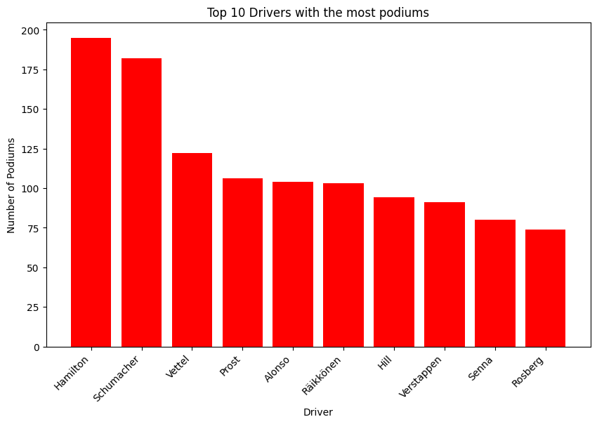

```python
plt.figure(figsize=(10, 6))
plt.bar(driver_podium_final['surname'], driver_podium_final['count'], color='red')
plt.xlabel('Driver')
plt.ylabel('Number of Podiums')
plt.title('Top 10 Drivers with the most podiums')
plt.xticks(rotation=45, ha='right')
plt.show()
```

## Query 8

The higher you finish in a race the more points you get and ultimalty that is how you win chamionships. Howeveer, may driver have had very successful seasons without winning a race. FOr this query we will see who has been the most seuccseful at acheiving point but has failed to get that all important race win. This will exclude sprint data.

**Possible Errors:** The point sytem has evolved drastically over time due to changes in number of drivers participating in a race and there have been races where half points were awarded. The data is likely to show more recent drivers due to higher points being awarded and more races taking place in a season.

We will use the 'race_results_driver' table to first select columns we need , points, position and driver information, and filter out those who have won

```python
columns=['driverRef', 'surname', 'points']
winners=races_results_drivers[races_results_drivers['positionOrder']==1]
winners=winners['driverRef']
no_win= races_results_drivers[races_results_drivers['positionOrder']!=1]
no_win=no_win[columns]
no_win
```

|  | driverRef | surname | points |
| --- | --- | --- | --- |
| 2 | button | Button | 6.0 |
| 7 | button | Button | 3.0 |
| 8 | button | Button | 4.0 |
| 9 | button | Button | 2.0 |
| 10 | button | Button | 2.0 |
| ... | ... | ... | ... |
| 26075 | piastri | Piastri | 0.0 |
| 26076 | piastri | Piastri | 0.0 |
| 26077 | piastri | Piastri | 12.0 |
| 26078 | piastri | Piastri | 10.0 |
| 26079 | piastri | Piastri | 0.0 |

24986 rows × 3 columns

We have a table, winners containing all wins, and a table , no_win, containing all results without a win. Next we will merge the table and drop all drivers who appear in both tables which create a table of those without race wins.

```python
# Merge
non_winners = pd.merge(no_win, winners, on='driverRef', how='left', indicator=True)

# Filter out the rows where the driver is present in both tables
non_winners = non_winners[non_winners['_merge'] == 'left_only'].drop('_merge', axis=1)

non_winners
```

|  | driverRef | surname | points |
| --- | --- | --- | --- |
| 8130 | glock | Glock | 5.0 |
| 8131 | glock | Glock | 3.0 |
| 8132 | glock | Glock | 2.0 |
| 8133 | glock | Glock | 2.0 |
| 8134 | glock | Glock | 0.0 |
| ... | ... | ... | ... |
| 189287 | piastri | Piastri | 0.0 |
| 189288 | piastri | Piastri | 0.0 |
| 189289 | piastri | Piastri | 12.0 |
| 189290 | piastri | Piastri | 10.0 |
| 189291 | piastri | Piastri | 0.0 |

12304 rows × 3 columns

Now that we have a table containing only driver's without a Grand Prix win. We can now calculate their total points and sort the data.

```python
total_points = non_winners.groupby('surname')['points'].sum().reset_index()
total_points = total_points.sort_values(by='points', ascending=False)
total_points= total_points.head(10)
total_points
```

|  | surname | points |
| --- | --- | --- |
| 305 | Hülkenberg | 527.0 |
| 457 | Norris | 488.0 |
| 261 | Grosjean | 391.0 |
| 286 | Heidfeld | 259.0 |
| 596 | Stroll | 235.0 |
| 10 | Albon | 212.0 |
| 343 | Kvyat | 202.0 |
| 393 | Magnussen | 182.0 |
| 338 | Kobayashi | 125.0 |
| 602 | Sutil | 124.0 |

Here we can see Niko Hulkenberg and Lando Norris unfortunatley lead the way with this stat. Lucky for them they are both still on the grid so hopefully their fortunes can change next season.

Here is the data represented in a scatterplot:

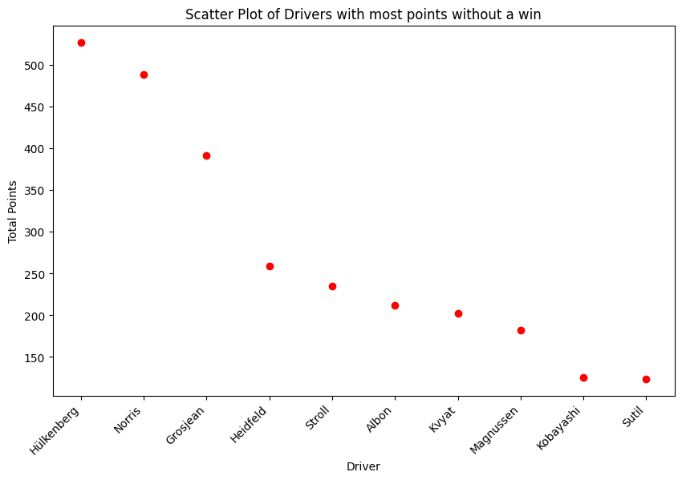

```python
plt.figure(figsize=(10, 6))
plt.scatter(total_points['surname'], total_points['points'], color='red')
plt.xlabel('Driver')
plt.ylabel('Total Points')
plt.title('Scatter Plot of Drivers with most points without a win')
plt.xticks(rotation=45, ha='right')
plt.show()
```